# Practical Machine Learning Course Project

Vicky C

2022-08-02

## Synopsis

In this project, the goal is to use data from accelerometers on the belt, forearm, arm, and dumbbell of 6 participants to create a prediction model that will be used to predict 20 different test cases.

## Data Processing

```r
library(knitr)
library(ggplot2)
library(caret)
library(rpart.plot)
library(rattle)
library(gbm)
pml_training <- read.csv("C:/Users/VickyCastro/Downloads/pml-training.csv", na.strings= c("NA","","#DIV/0!"))
pml_testing <- read.csv("C:/Users/VickyCastro/Downloads/pml-testing.csv", na.strings= c("NA","","#DIV/0!"))
```

Remove all NA and blank values and then remove all unnecessary variables for each dataset.

```r
pml_training <- pml_training[,colSums(is.na(pml_training)) == 0]
dim(pml_training)
```

```
## [1] 19622    60
```

```r
pml_testing <- pml_testing[,colSums(is.na(pml_testing)) == 0]
dim(pml_testing)
```

```
## [1] 20 60
```

```r
pml_training <- pml_training[,-c(1:7)]
dim(pml_training)
```

```
## [1] 19622    53
```

```r
pml_testing <- pml_testing[,-c(1:7)]
dim(pml_testing)
```

```
## [1] 20 53
```

## Building Model and Using Cross Validation

Split the training data into two so that only can be used to train the model and the second can be used as a validation set.

```r
training_set <- createDataPartition(pml_training$classe, p = 0.6, list = FALSE)
newTrain <- pml_training[training_set,]
newTest <- pml_training[-training_set,]

dim(newTrain)
```

```
## [1] 11776    53
```

```r
dim(newTest)
```

```
## [1] 7846   53
```

Create a control by using the k-fold cross validation process.

```r
control <- trainControl(method="cv", number=3)
```

We will now use three methods to build a model: Decision Trees, Random Forests, and Generalized Boosted Model.

### Decision Trees

First, we will build a decision tree model using the newTrain data.

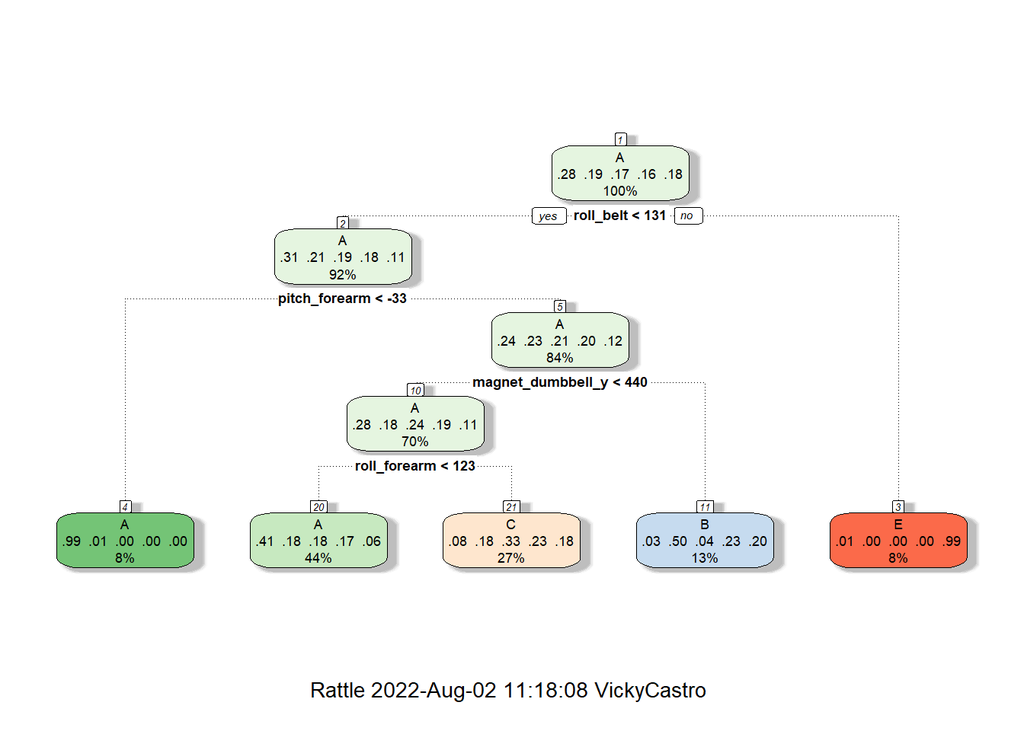

```r
set.seed(1234)
DT_model <- train(classe~., data=newTrain, method="rpart", trControl=control)
fancyRpartPlot(DT_model$finalModel)
```

We will use the validation “newTest” data to see the accuracy of the decision tree model using a confusion matrix.

```r
newTest$classe <- as.factor(newTest$classe)

DT_predict <- predict(DT_model, newdata = newTest)
DT_matrix <- confusionMatrix(newTest$classe, DT_predict)

DT_matrix
```

```
## Confusion Matrix and Statistics
##
##           Reference
## Prediction    A    B    C    D    E
##          A 2032   29  166    0    5
##          B  630  515  373    0    0
##          C  657   41  670    0    0
##          D  574  221  491    0    0
##          E  211  186  388    0  657
##
## Overall Statistics
##
##                Accuracy : 0.4938
##                  95% CI : (0.4826, 0.5049)
##     No Information Rate : 0.5231
##     P-Value [Acc > NIR] : 1
##
##                   Kappa : 0.3381
##
##  Mcnemar's Test P-Value : NA
##
## Statistics by Class:
##
##                      Class: A Class: B Class: C Class: D Class: E
## Sensitivity            0.4951  0.51915  0.32088       NA  0.99245
## Specificity            0.9466  0.85366  0.87878   0.8361  0.89073
## Pos Pred Value         0.9104  0.33926  0.48977       NA  0.45562
## Neg Pred Value         0.6309  0.92462  0.78111       NA  0.99922
## Prevalence             0.5231  0.12643  0.26612   0.0000  0.08437
## Detection Rate         0.2590  0.06564  0.08539   0.0000  0.08374
## Detection Prevalence   0.2845  0.19347  0.17436   0.1639  0.18379
## Balanced Accuracy      0.7208  0.68641  0.59983       NA  0.94159
```

### Random Forests

First, we will build the random forest model using the newTrain data.

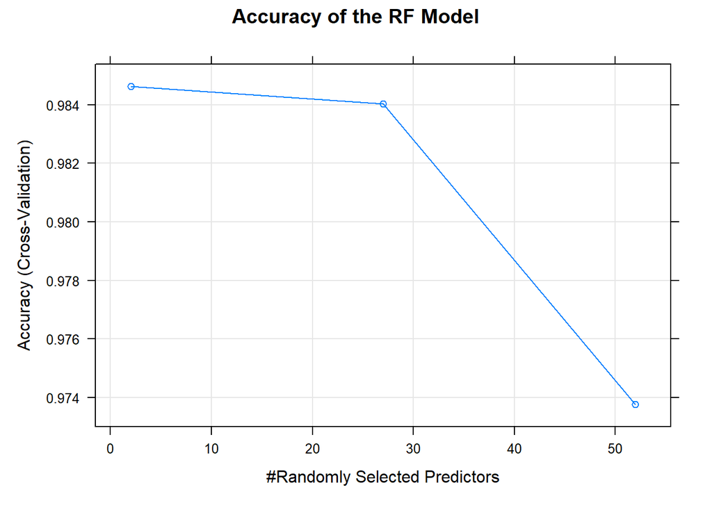

```r
set.seed(1234)
RF_model <- train(classe~., data=newTrain, method="rf", trControl=control, verbose = FALSE)
plot(RF_model, main = "Accuracy of the RF Model")
```

We will use the validation “newTest” data to see the accuracy of the random forest model using a confusion matrix.

```r
RF_predict <- predict(RF_model, newdata = newTest)
RF_matrix <- confusionMatrix(newTest$classe, RF_predict)

RF_matrix
```

```
## Confusion Matrix and Statistics
##
##           Reference
## Prediction    A    B    C    D    E
##          A 2227    5    0    0    0
##          B   21 1488    9    0    0
##          C    0    8 1359    1    0
##          D    0    0   22 1261    3
##          E    0    0    1    2 1439
##
## Overall Statistics
##
##                Accuracy : 0.9908
##                  95% CI : (0.9885, 0.9928)
##     No Information Rate : 0.2865
##     P-Value [Acc > NIR] : < 2.2e-16
##
##                   Kappa : 0.9884
##
##  Mcnemar's Test P-Value : NA
##
## Statistics by Class:
##
##                      Class: A Class: B Class: C Class: D Class: E
## Sensitivity            0.9907   0.9913   0.9770   0.9976   0.9979
## Specificity            0.9991   0.9953   0.9986   0.9962   0.9995
## Pos Pred Value         0.9978   0.9802   0.9934   0.9806   0.9979
## Neg Pred Value         0.9963   0.9979   0.9951   0.9995   0.9995
## Prevalence             0.2865   0.1913   0.1773   0.1611   0.1838
## Detection Rate         0.2838   0.1897   0.1732   0.1607   0.1834
## Detection Prevalence   0.2845   0.1935   0.1744   0.1639   0.1838
## Balanced Accuracy      0.9949   0.9933   0.9878   0.9969   0.9987
```

### Generalized Boosted Model

First, we will build the Generalized Boosted Model using the newTrain data.

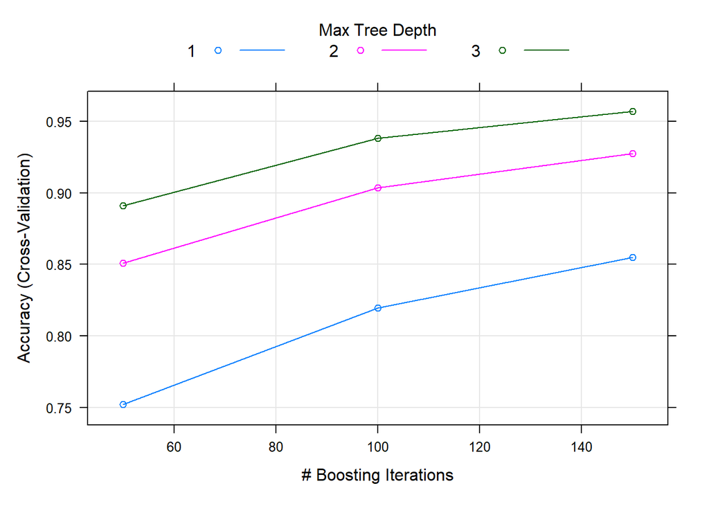

```r
set.seed(1234)
GBM_model <- train(classe~., data=newTrain, method="gbm", trControl=control, verbose=FALSE)
plot(GBM_model)
```

We will use the validation “newTest” data to see the accuracy of the GBM using a confusion matrix.

```r
GBM_predict <- predict(GBM_model, newdata = newTest)
GBM_matrix <- confusionMatrix(newTest$classe, GBM_predict)

GBM_matrix
```

```
## Confusion Matrix and Statistics
##
##           Reference
## Prediction    A    B    C    D    E
##          A 2191   30    9    1    1
##          B   58 1411   47    1    1
##          C    0   48 1301   17    2
##          D    2   12   43 1215   14
##          E    2   22   11   23 1384
##
## Overall Statistics
##
##                Accuracy : 0.9562
##                  95% CI : (0.9514, 0.9606)
##     No Information Rate : 0.2872
##     P-Value [Acc > NIR] : < 2.2e-16
##
##                   Kappa : 0.9445
##
##  Mcnemar's Test P-Value : 1.869e-10
##
## Statistics by Class:
##
##                      Class: A Class: B Class: C Class: D Class: E
## Sensitivity            0.9725   0.9265   0.9220   0.9666   0.9872
## Specificity            0.9927   0.9831   0.9896   0.9892   0.9910
## Pos Pred Value         0.9816   0.9295   0.9510   0.9448   0.9598
## Neg Pred Value         0.9890   0.9823   0.9830   0.9936   0.9972
## Prevalence             0.2872   0.1941   0.1798   0.1602   0.1787
## Detection Rate         0.2793   0.1798   0.1658   0.1549   0.1764
## Detection Prevalence   0.2845   0.1935   0.1744   0.1639   0.1838
## Balanced Accuracy      0.9826   0.9548   0.9558   0.9779   0.9891
```

## Results

After comparing the accuracy of each model, the random forest model is the best model to accurately predict the class outcome. Therefore, we will run this model against the original test set (pml_testing).

```r
predictTestSet <- predict(RF_model, pml_testing)
print(predictTestSet)
```

```
##  [1] B A B A A E D B A A B C B A E E A B B B
## Levels: A B C D E
```